# Du Bois Visualization Challenge: 2024

The goal of the challenge is to celebrate the data visualization legacy of W.E.B Du Bois by recreating the visualizations from the 1900 Paris Exposition using modern tools.

This directory contains the data and original plates from the exposition; your goal is to re-create the visualizations using modern tools of your choice (Tableau, R, ggplot, Stata, PowerBI, decksh, etc)

There is a folder for each challenge, which includes the images of the 1900 original plates along with the corresponding data. You may submit your re-creations to social media using the hash tag #DuBoisChallenge2024.

Note that for 2024, the challenge will occur on X (formally Twitter), Data Visualization Society Slack, Instagram, as well as Mastadon on vis.social.

## The Challenges

This year the theme for the challenge will be organized around the colors of the Pan African flag: Challenges 1-3: red, Challenges 4-6: black, Challenges 7-9: green, Challenge 10: a combination.

## Red Challenge

### Challenge 01 - Negro Population of Georgia by Counties, 1870, 1880 (plate 06), February 5

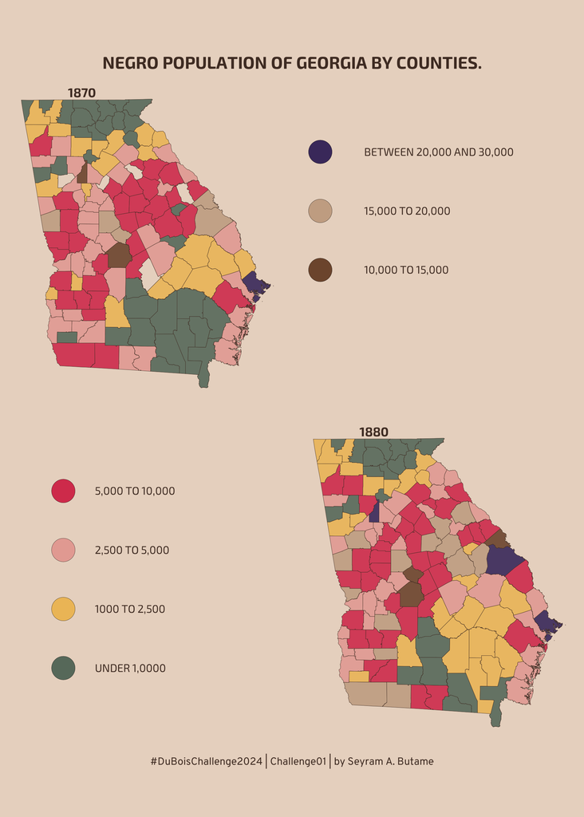

Challenge 01

## Challenge 02 - Slave and Free Negroes (plate 12), February 12

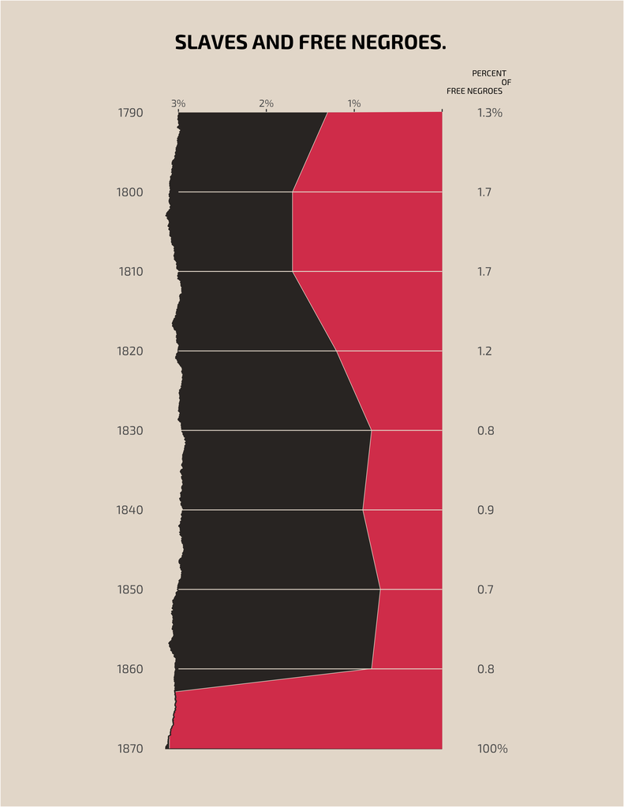

Challenge 02

## Challenge 03 - challenge03: Acres of Land Owned by Negroes in Georgia (plate 19), February 19

[figure not shown]

image

Source: https://github.com/ajstarks/dubois-data-portraits/tree/master/challenge/2024